# Data Mining Project- Group 12

Goutham Yallapu & Monish Pinapala

2023-10-30

```r
knitr::opts_chunk$set(echo = TRUE)
```

## Loading the dataset

```r
library(readxl)

Retaildata <- read.csv("sample2retail.csv")
```

## Dimension of the dataset

```r
dim(Retaildata)
```

```
## [1] 230000      9
```

```r
number_of_obs <- nrow(Retaildata)
number_of_var <- ncol(Retaildata)

cat("There are ", number_of_obs,"observations and there are", number_of_var, "variables in the dataset")
```

```
## There are  230000 observations and there are 9 variables in the dataset
```

## Data Exploration

```r
#Changing datatype

library(dplyr)
library(lubridate)


Retaildata$InvoiceNo <- as.factor(Retaildata$InvoiceNo)
Retaildata$StockCode <- as.factor(Retaildata$StockCode)
Retaildata$CustomerID <- as.factor(Retaildata$CustomerID)
Retaildata$InvoiceDate <- as.Date(Retaildata$InvoiceDate, format = "%m/%d/%y")
```

```r
str(Retaildata)
```

```
## 'data.frame':    230000 obs. of  9 variables:
##  $ X          : int  1 2 3 4 5 6 7 8 9 10 ...
##  $ InvoiceNo  : Factor w/ 21646 levels "536365","536367",..: 9638 10321 1772 13076 18363 19249 18126 1987 5150 16871 ...
##  $ StockCode  : Factor w/ 3868 levels "10002","10080",..: 1148 1950 165 2140 1215 465 295 3116 1018 2100 ...
##  $ Description: chr  "JIGSAW TREE WITH BIRDHOUSE" "RABBIT NIGHT LIGHT" "JUMBO BAG WOODLAND ANIMALS" "DOLLY GIRL CHILDRENS CUP" ...
##  $ Quantity   : int  4 1 10 96 1 1 2 6 12 6 ...
##  $ InvoiceDate: Date, format: "2020-07-06" "2020-07-21" ...
##  $ UnitPrice  : num  1.25 4.13 1.95 1.05 4.96 5.79 0.65 1.25 2.95 4.15 ...
##  $ CustomerID : Factor w/ 4289 levels "12346","12347",..: NA NA 2912 1677 1278 NA 3974 1383 1854 109 ...
##  $ Country    : chr  "United Kingdom" "United Kingdom" "United Kingdom" "Netherlands" ...
```

```r
head(Retaildata)
```

```
##   X InvoiceNo StockCode                     Description Quantity InvoiceDate
## 1 1    559162     22231      JIGSAW TREE WITH BIRDHOUSE        4  2020-07-06
## 2 2    560778     23084              RABBIT NIGHT LIGHT        1  2020-07-21
## 3 3    540750     20712      JUMBO BAG WOODLAND ANIMALS       10  2020-01-11
## 4 4    567290     23291        DOLLY GIRL CHILDRENS CUP       96  2020-09-19
## 5 5    579196     22308            TEA COSY BLUE STRIPE        1  2020-11-28
## 6 6    581217     21249 WOODLAND  HEIGHT CHART STICKERS        1  2020-12-08
##   UnitPrice CustomerID        Country
## 1      1.25       <NA> United Kingdom
## 2      4.13       <NA> United Kingdom
## 3      1.95      16351 United Kingdom
## 4      1.05      14646    Netherlands
## 5      4.96      14096 United Kingdom
## 6      5.79       <NA> United Kingdom
```

```r
library(stringr)

# Converting the Description to title case

Retaildata$Description <- str_to_title(Retaildata$Description)
Retaildata$Country <- ifelse(Retaildata$Country == "United Kingdom", "UK", Retaildata$Country)
```

## Handling missing data

```r
missing_obs <- sum(is.na(Retaildata))

cat("There are ", missing_obs,"missing observations in the dataset")
```

```
## There are  57626 missing observations in the dataset
```

```r
#Missing data from eacvh variable
missingvalues <- data.frame(
  Variable = c("InvoiceNo", "StockCode", "Description", "Quantity", "InvoiceDate", "UnitPrice", "CustomerID", "Country"),
  NA_Count = c(
    sum(is.na(Retaildata$InvoiceNo)),
    sum(is.na(Retaildata$StockCode)),
    sum(is.na(Retaildata$Description)),
    sum(is.na(Retaildata$Quantity)),
    sum(is.na(Retaildata$InvoiceDate)),
    sum(is.na(Retaildata$UnitPrice)),
    sum(is.na(Retaildata$CustomerID)),
    sum(is.na(Retaildata$Country))
  )
)

knitr::kable(missingvalues)
```

| Variable | NA_Count |
| --- | --- |
| InvoiceNo | 0 |
| StockCode | 0 |
| Description | 619 |
| Quantity | 0 |
| InvoiceDate | 0 |
| UnitPrice | 0 |
| CustomerID | 57007 |
| Country | 0 |

```r
Retaildataupdated <- na.omit(Retaildata)
Retaildataupdated <- Retaildataupdated[,-1]

sum(is.na(Retaildataupdated))
```

```
## [1] 0
```

```r
dim(Retaildataupdated)
```

```
## [1] 172993      8
```

##### After omitting the null observations, dataset is left with 172,993 observations with 8 variables. We can further look for outliers with the visualizations

## Data visulaizations

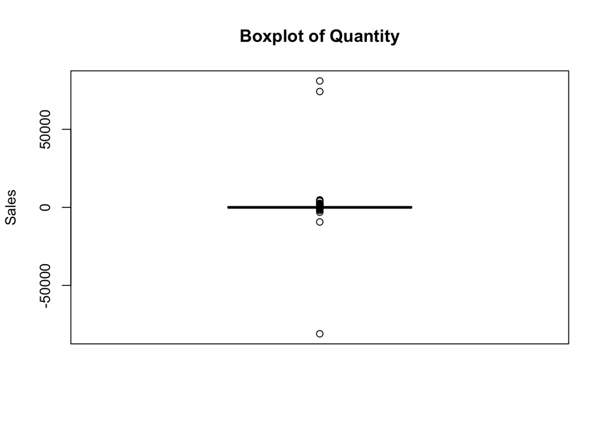

```r
Retaildataupdated$Totalsales <- Retaildataupdated$UnitPrice * Retaildataupdated$Quantity

Qty_boxplot <- boxplot(Retaildataupdated$Quantity,
        main="Boxplot of Quantity",
        ylab="Sales",
        col="lightblue",
        notch=FALSE)
```

#### The above is a boxplot of Quantity to find outliers if any. Here we can see that there are a few outliers that lie way above the median value on either side of the median. The median is closer to the bottom of the box, indicating that most of the orders contain smaller quantities, which further suggests that the distribution is skewed. Errors in data entry or bulk purchases may be the cause of outliers, especially those that are extreme. To determine the nature of these issues and the best course of action, such as data transformation or cleaning, more research will be required. And these outliers needs to be omitted to have better predictive analysis and no biases.

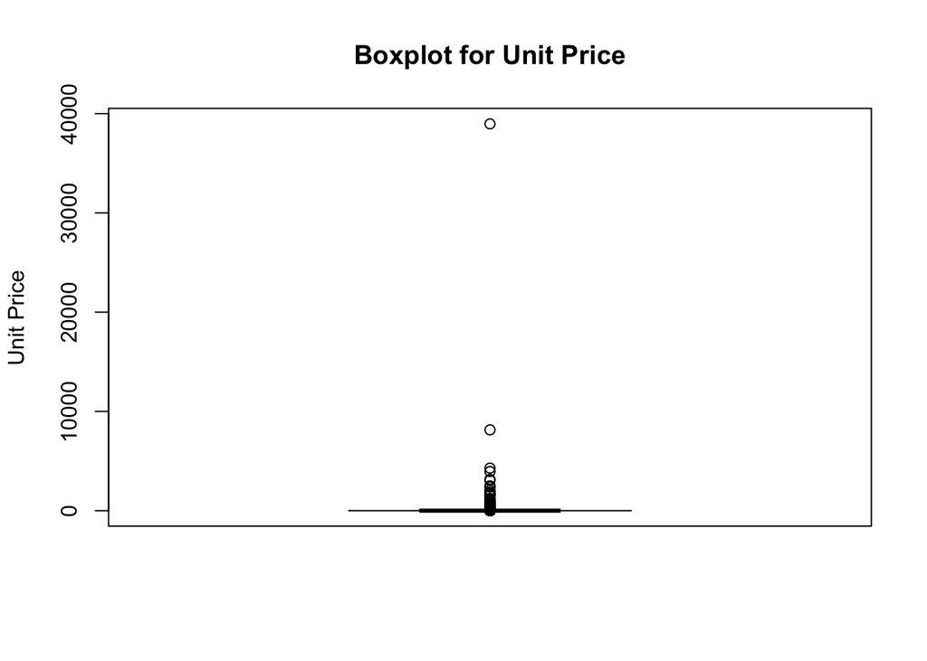

```r
Price_boxplot <- boxplot(Retaildataupdated$UnitPrice,
        main = "Boxplot for Unit Price",
        ylab = "Unit Price",
        col = "lightgreen",
        notch = TRUE)
```

#### At least half of the unit prices are in the lower half of the price range, as indicated by the median, or the box’s central line, which is extremely close to the bottom of the box.The box itself represents the interquartile range (IQR), which is quite narrow, indicating that the middle 50% of the prices are concentrated within a narrow range.

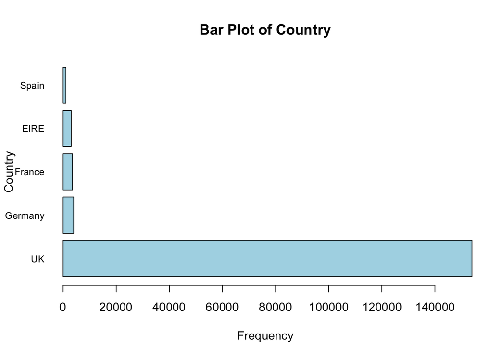

```r
# Bar plot for Country
country_freq <- table(Retaildataupdated$Country)
country_freq <- sort(country_freq, decreasing = TRUE)
top_country_freq <- head(country_freq,5)

barplot(top_country_freq,
        main="Bar Plot of Country",
        xlab="Frequency",
        ylab="Country",
        horiz = TRUE,
        las=1,
        cex.names = 0.8,
        col="lightblue")
```

#### Based on this plot, we can deduce: By a wide margin, the UK has the highest frequency, which suggests that it has the highest count of the variable under study (for example, the most sales or customers). The next highest frequency, though still far lower than the UK, is Germany. The frequencies are progressively lower in France, EIRE (Ireland), and Spain, that order. When compared to the other listed countries, the UK appears to have a higher concentration of the variable, as indicated by the significant difference in frequencies.

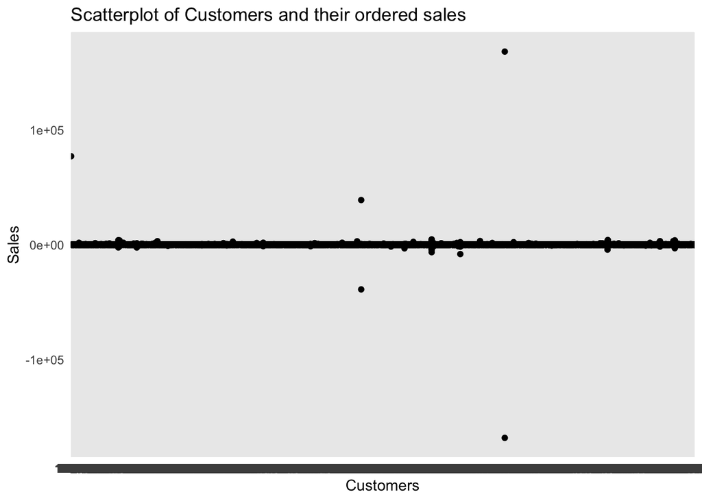

```r
library(ggplot2)

scatterplot <- ggplot(Retaildataupdated, aes(x = CustomerID, y = Totalsales)) +
  geom_point() +
  labs(title = "Scatterplot of Customers and their ordered sales", x = "Customers", y = "Sales") +
  theme_minimal()
scatterplot
```

#### A significant portion of the customer base has low sales volumes, as seen by the visualization, which shows that most customers are concentrated around the lower sales values close to zero. Points higher up on the y-axis represent a few customers with larger sales volumes. These might be seen as high-value clients or possibly more significant one-time purchases.The plot also displays a few outliers that have sales that are noticeably higher than average. These could be major accounts that differ greatly from the typical customer base or purchases made in bulk.

```r
# Calculatting and filtering the data with Quantity

IQR_Totalsales <- IQR(Retaildataupdated$Totalsales, na.rm = TRUE)
Q1_Totalsales <- quantile(Retaildataupdated$Totalsales, 0.25, na.rm = TRUE)
Q3_Totalsales <- quantile(Retaildataupdated$Totalsales, 0.75, na.rm = TRUE)


lower_bound_Totalsales <- Q1_Totalsales - 3 * IQR_Totalsales
upper_bound_Totalsales <- Q3_Totalsales + 3 * IQR_Totalsales

Retaildatafiltered <- Retaildataupdated[Retaildataupdated$Totalsales >= lower_bound_Totalsales & Retaildataupdated$Totalsales <= upper_bound_Totalsales,]
```

```r
library(dplyr)

Retaildatafiltered <- Retaildatafiltered %>% filter(UnitPrice >= 0.01)
```

## Creating new variables

```r
Retaildatafiltered$GroupedCountry <- ifelse(Retaildatafiltered$Country == "UK", "UK", "Other")

getSeason <- function(date) {
  month <- as.numeric(format(date, "%m"))
  if (month %in% 3:5) {
    return("Spring")
  } else if (month %in% 6:8) {
    return("Summer")
  } else if (month %in% 9:11) {
    return("Fall")
  } else {
    return("Winter")
  }
}

# Apply the function to create a new 'Season' column
Retaildatafiltered$Season <- sapply(Retaildatafiltered$InvoiceDate, getSeason)

# Check the result
table(Retaildatafiltered$Season)
```

```
##
##   Fall Spring Summer Winter
##  63678  31969  33299  34882
```

```r
dim(Retaildatafiltered)
```

```
## [1] 163828     11
```

```r
number_of_obs1 <- nrow(Retaildatafiltered)
number_of_var1 <- ncol(Retaildatafiltered)

cat("There are ", number_of_obs1,"observations and there are", number_of_var1, "variables in the dataset after handling outliers")
```

```
## There are  163828 observations and there are 11 variables in the dataset after handling outliers
```

```r
Retaildatafiltered$InvoiceDummy <- ifelse(substr(Retaildatafiltered$InvoiceNo, 1, 1) == 'C', 1, 0)

table(Retaildatafiltered$InvoiceDummy)
```

```
##
##      0      1
## 160485   3343
```

## Dividing the dataset into Retail Sales and Retail return sales

```r
Retail_sales <- Retaildatafiltered %>%
  filter(InvoiceDummy == 0)

head(Retail_sales)
```

```
##   InvoiceNo StockCode                         Description Quantity InvoiceDate
## 1    540750     20712          Jumbo Bag Woodland Animals       10  2020-01-11
## 2    579196     22308                Tea Cosy Blue Stripe        1  2020-11-28
## 3    578678     20975 12 Pencils Small Tube Red Retrospot        2  2020-11-24
## 4    541357     84799    Sprig Lavender Artificial Flower        6  2020-01-17
## 5    548743     22087            Paper Bunting White Lace       12  2020-04-04
## 6    575896     23239   Set Of 4 Knick Knack Tins Poppies        6  2020-11-11
##   UnitPrice CustomerID Country Totalsales GroupedCountry Season InvoiceDummy
## 1      1.95      16351      UK      19.50             UK Winter            0
## 2      4.96      14096      UK       4.96             UK   Fall            0
## 3      0.65      17841      UK       1.30             UK   Fall            0
## 4      1.25      14238      UK       7.50             UK Winter            0
## 5      2.95      14895      UK      35.40             UK Spring            0
## 6      4.15      12480 Germany      24.90          Other   Fall            0
```

```r
Retail_return <- Retaildatafiltered %>%
  filter(InvoiceDummy == 1)

head(Retail_return)
```

```
##   InvoiceNo StockCode                       Description Quantity InvoiceDate
## 1   C555105     22726        Alarm Clock Bakelike Green       -1  2020-05-31
## 2   C545432     22220  Cake Stand Lovebird 2 Tier White       -1  2020-03-02
## 3   C557927         D                          Discount       -1  2020-06-23
## 4   C578039     21843          Red Retrospot Cake Stand       -1  2020-11-22
## 5   C548906    85131A Beaded Pearl Heart White On Stick       -6  2020-04-05
## 6   C569114     23170           Regency Tea Plate Roses       -1  2020-09-30
##   UnitPrice CustomerID Country Totalsales GroupedCountry Season InvoiceDummy
## 1      3.75      17841      UK      -3.75             UK Spring            1
## 2      9.95      14657      UK      -9.95             UK Spring            1
## 3     10.00      16029      UK     -10.00             UK Summer            1
## 4     10.95      17338      UK     -10.95             UK   Fall            1
## 5      1.25      13636      UK      -7.50             UK Spring            1
## 6      1.65      14911    EIRE      -1.65          Other   Fall            1
```

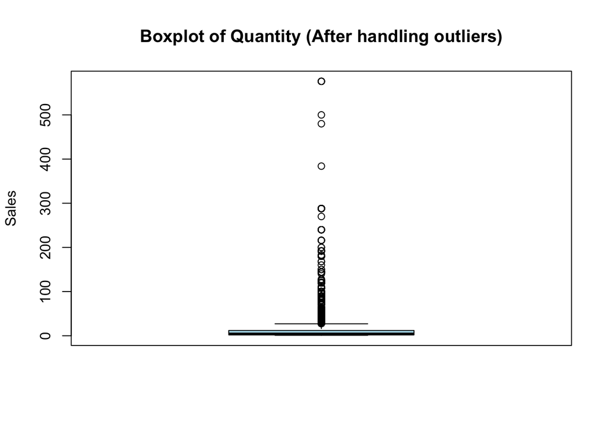

```r
Qty_boxplot_nooutliers <- boxplot(Retail_sales$Quantity,
        main="Boxplot of Quantity (After handling outliers)",
        ylab="Sales",
        col="lightblue",
        notch=FALSE)
```

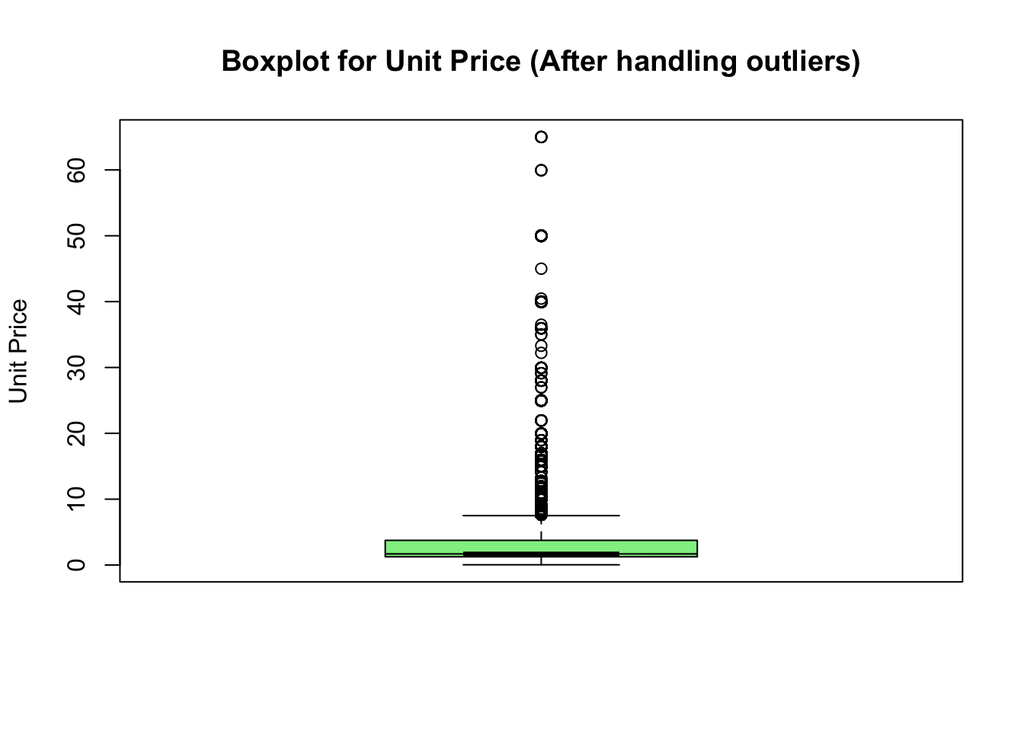

```r
Price_boxplot_nooutliers <- boxplot(Retail_sales$UnitPrice,
        main = "Boxplot for Unit Price (After handling outliers)",
        ylab = "Unit Price",
        col = "lightgreen",
        notch = TRUE)
```

#### Similar to quantity, UnitPrice has also seen a significant difference in its median after omitting the extreme outliers.

```r
Retail_sales$Log_Totalsales <- log(Retail_sales$Quantity)
Retail_sales$Log_UnitPrice <- log(Retail_sales$UnitPrice)

head(Retail_sales)
```

```
##   InvoiceNo StockCode                         Description Quantity InvoiceDate
## 1    540750     20712          Jumbo Bag Woodland Animals       10  2020-01-11
## 2    579196     22308                Tea Cosy Blue Stripe        1  2020-11-28
## 3    578678     20975 12 Pencils Small Tube Red Retrospot        2  2020-11-24
## 4    541357     84799    Sprig Lavender Artificial Flower        6  2020-01-17
## 5    548743     22087            Paper Bunting White Lace       12  2020-04-04
## 6    575896     23239   Set Of 4 Knick Knack Tins Poppies        6  2020-11-11
##   UnitPrice CustomerID Country Totalsales GroupedCountry Season InvoiceDummy
## 1      1.95      16351      UK      19.50             UK Winter            0
## 2      4.96      14096      UK       4.96             UK   Fall            0
## 3      0.65      17841      UK       1.30             UK   Fall            0
## 4      1.25      14238      UK       7.50             UK Winter            0
## 5      2.95      14895      UK      35.40             UK Spring            0
## 6      4.15      12480 Germany      24.90          Other   Fall            0
##   Log_Totalsales Log_UnitPrice
## 1      2.3025851     0.6678294
## 2      0.0000000     1.6014057
## 3      0.6931472    -0.4307829
## 4      1.7917595     0.2231436
## 5      2.4849066     1.0818052
## 6      1.7917595     1.4231083
```

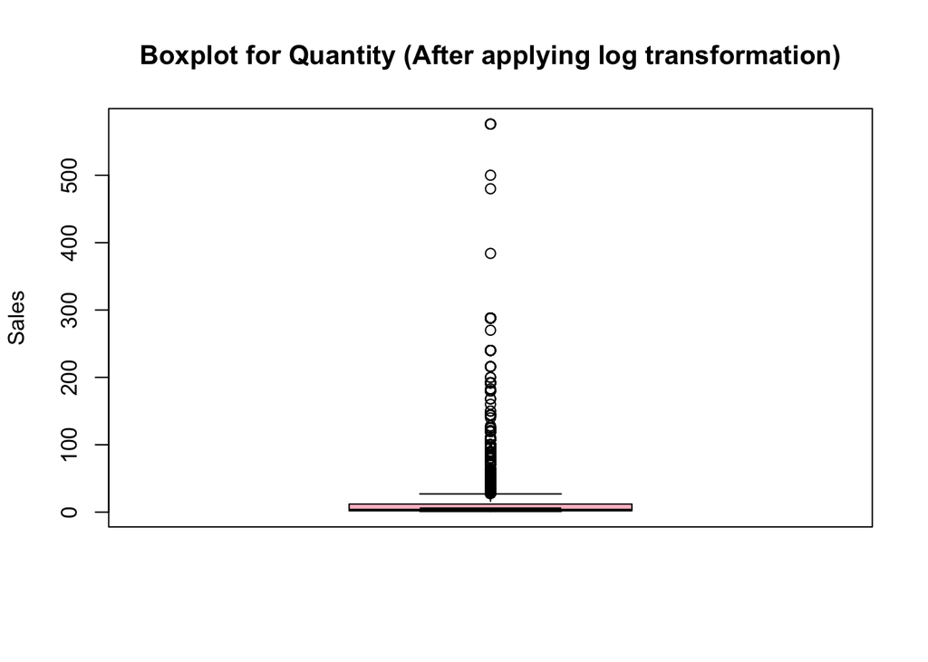

```r
Totalsales_boxplot_nooutliers2 <- boxplot(Retail_sales$Quantity,
        main = "Boxplot for Quantity (After applying log transformation)",
        ylab = "Sales",
        col = "pink",
        notch = TRUE)
```

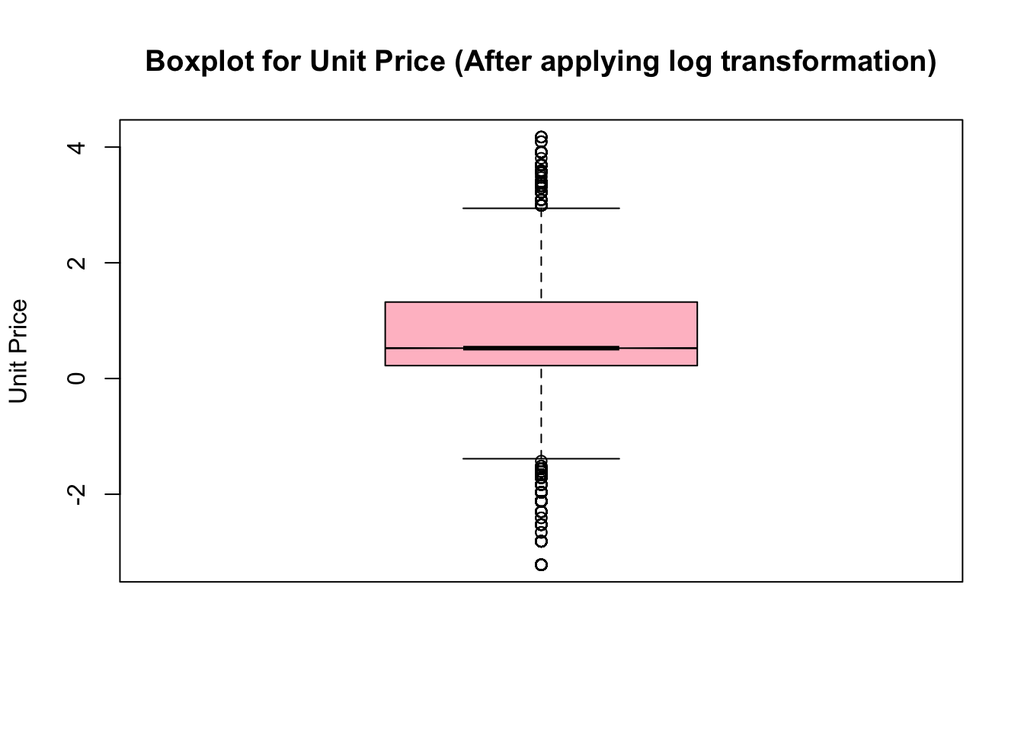

```r
Price_boxplot_nooutliers2 <- boxplot(Retail_sales$Log_UnitPrice,
        main = "Boxplot for Unit Price (After applying log transformation)",
        ylab = "Unit Price",
        col = "pink",
        notch = TRUE)
```

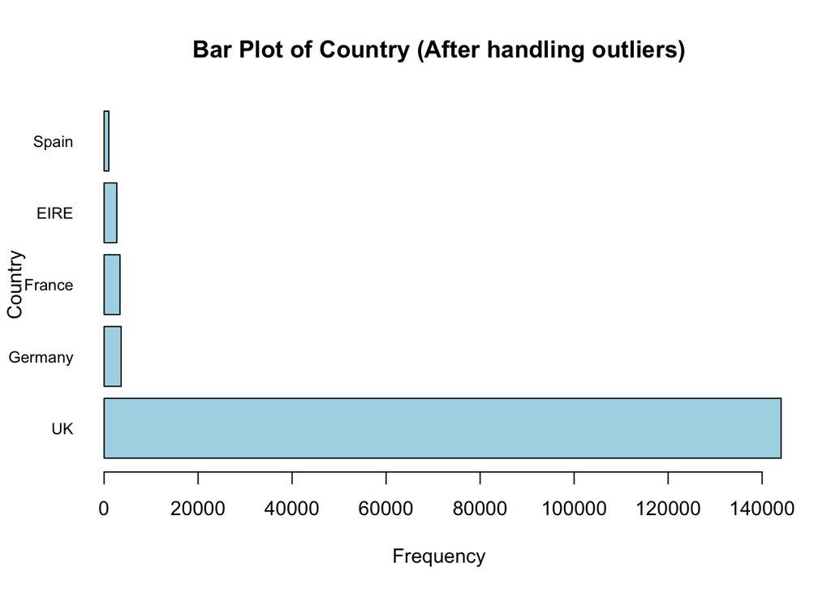

```r
country_freq2 <- table(Retail_sales$Country)
country_freq2 <- sort(country_freq2, decreasing = TRUE)
top_country_freq2 <- head(country_freq2, 5)

barplot(top_country_freq2,
        main="Bar Plot of Country (After handling outliers)",
        xlab="Frequency",
        ylab="Country",
        horiz = TRUE,
        las=1,
        cex.names = 0.8,
        col="lightblue")
```

#### Bar plot of countries with most frequent buyers after omitting the outliers, although UK still stays on top, Germany and France has occupied the second and third positions with not a major difference between the two.

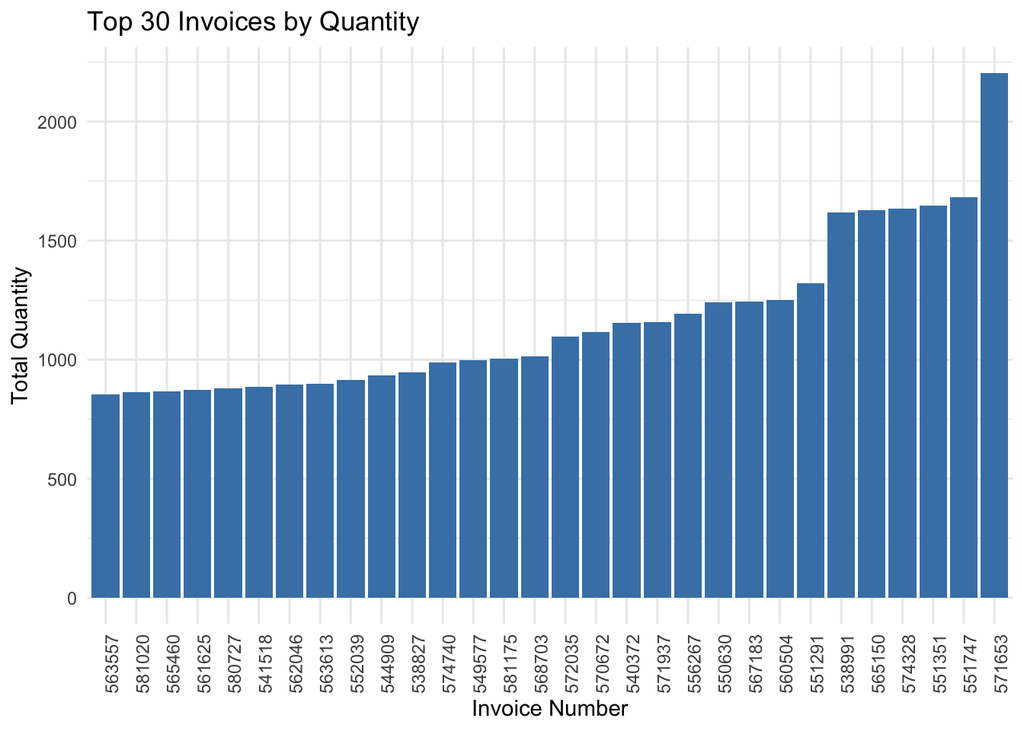

```r
total_quantities <- aggregate(Quantity ~ InvoiceNo, data = Retail_sales, FUN = sum)

total_quantities <- total_quantities[order(-total_quantities$Quantity), ]

# Selecting the top 30 invoices for plotting
num <- 30
top_invoices <- head(total_quantities, num)

# Creating a bar chart of invoices by quantity
ggplot(top_invoices, aes(x = reorder(InvoiceNo, Quantity), y = Quantity)) +
  geom_bar(stat = "identity", fill = "steelblue") +
  theme_minimal() +
  labs(title = paste("Top", num, "Invoices by Quantity"),
       x = "Invoice Number",
       y = "Total Quantity") +
  theme(axis.text.x = element_text(angle = 90, hjust = 1))
```

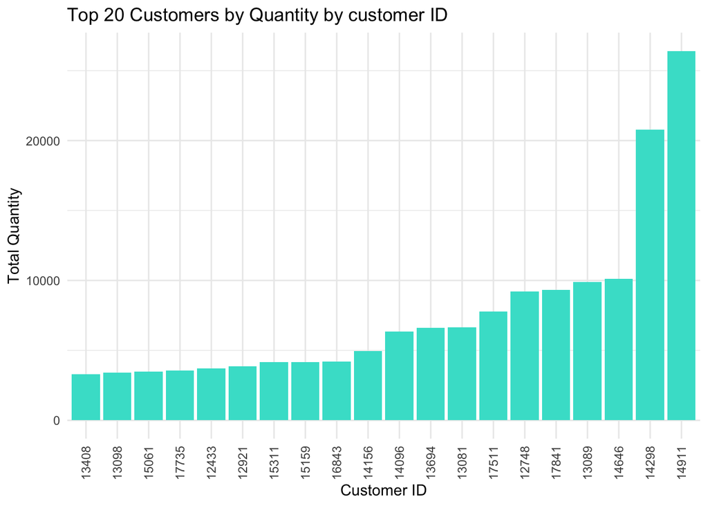

```r
total_quantities_by_customer <- aggregate(Quantity ~ CustomerID, data = Retail_sales, FUN = sum)

total_quantities_by_customer <- total_quantities_by_customer[order(-total_quantities_by_customer$Quantity), ]

# Selecting the top 20 customers by CustomerID for plotting
cus_num <- 20
top_customers_data <- head(total_quantities_by_customer, cus_num)

# Create a bar chart
ggplot(top_customers_data, aes(x = reorder(as.factor(CustomerID), Quantity), y = Quantity)) +
  geom_bar(stat = "identity", fill = "turquoise") +
  theme_minimal() +
  labs(title = paste("Top", cus_num, "Customers by Quantity by customer ID"),
       x = "Customer ID",
       y = "Total Quantity") +
  theme(axis.text.x = element_text(angle = 90, vjust = 0.5))
```

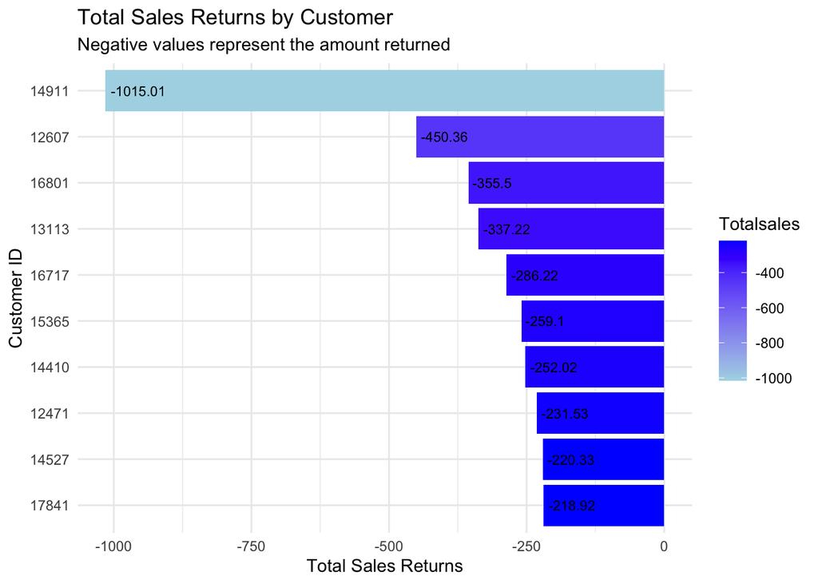

```r
total_sale_returns <- Retail_return %>%
  group_by(CustomerID) %>%
  summarise(Totalsales = sum(Totalsales)) %>%
  arrange(Totalsales)

highest_salereturns <- head(total_sale_returns, 10)

ggplot(highest_salereturns, aes(x = reorder(CustomerID, -Totalsales), y = Totalsales, fill = Totalsales)) +
  geom_bar(stat = "identity") +
  coord_flip() +
  scale_fill_gradient(low = "lightblue", high = "blue") +
  labs(title = "Total Sales Returns by Customer",
       subtitle = "Negative values represent the amount returned",
       x = "Customer ID",
       y = "Total Sales Returns") +
  theme_minimal() +
  geom_text(aes(label = Totalsales), hjust = -0.1, size = 3) +
  theme(axis.text.y = element_text(angle = 0))
```

#### The sales return amounts for different customers are shown in the chart, and the length of each bar represents the total value of returns. A longer bar denotes a larger return amount because the values are negative, in line with the note that they represent returns. With more than -1000 returns overall, customer 14911 has the most returns, which may point to a sizable volume of high-value or returned item returns. The return amounts of other customers are smaller, typically ranging from -200 to -450.

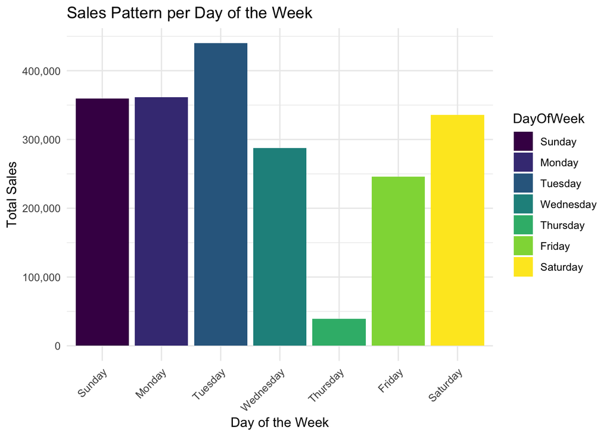

```r
library(lubridate)

Retaildatafiltered$DayOfWeek <- wday(Retaildatafiltered$InvoiceDate, label = TRUE, abbr = FALSE)

# Now aggregate sales by the day of the week
sales_pattern <- Retaildatafiltered %>%
  group_by(DayOfWeek) %>%
  summarize(Totalsales = sum(Totalsales, na.rm = TRUE)) %>%
  mutate(DayOfWeek = factor(DayOfWeek, levels = c("Sunday", "Monday", "Tuesday", "Wednesday", "Thursday", "Friday", "Saturday")))

ggplot(sales_pattern, aes(x = DayOfWeek, y = Totalsales, fill = DayOfWeek)) +
  geom_col() +
  labs(title = "Sales Pattern per Day of the Week", x = "Day of the Week", y = "Total Sales") +
  scale_y_continuous(labels = scales::comma) +
  theme_minimal() +
  theme(axis.text.x = element_text(angle = 45, hjust = 1))
```

#### The above bar chart shows the total sales for each day of the week. The height of each bar represent the total sales values which are colored visually. From this barchart, we can conclude that Tuesday appears to have the highest sales, which is followed by Monday and Sunday claiming second and third position. Thursday is the lowest among the weekdays. And this pattern interpreting that the beginning of the week is the strongest period for sales, with a dip in the middle of the week, and again picking up during the weekends.

```r
customer_summary <- aggregate(Totalsales ~ CustomerID, data=Retail_sales, FUN = sum)
```

```r
# Creating a correlation matrix with the filtered dataset

Correlation_data <- Retail_sales[, c('UnitPrice', 'Quantity', 'Totalsales')]

correlation_matrix_UnitpriceandQty <- cor(Correlation_data)

knitr::kable(correlation_matrix_UnitpriceandQty)
```

|  | UnitPrice | Quantity | Totalsales |
| --- | --- | --- | --- |
| UnitPrice | 1.0000000 | -0.2747769 | 0.2910981 |
| Quantity | -0.2747769 | 1.0000000 | 0.4241169 |
| Totalsales | 0.2910981 | 0.4241169 | 1.0000000 |

#### UnitPrice-Quantity: The correlation coefficient between the unit price of the items and the quantity sold is roughly -0.2748, suggesting a weakly negative linear relationship. The quantity sold typically declines slightly as the unit price rises, or vice versa. UnitPrice-Total Sales: There appears to be a slight positive linear relationship, as indicated by the correlation coefficient of roughly 0.2911. This could suggest that higher-priced items contribute more to the total sales value despite possibly lower quantities sold. It also means that as the unit price increases, the total sales value also tends to increase slightly. Quantity-Total-Sales: A moderately positive linear relationship is indicated by the correlation coefficient, which is roughly 0.4241. This makes sense because selling more things would normally result in a higher total sales value as the number of items sold rises.

```r
library(dplyr)
library(tidyr)

sales_product_pivot <- Retail_sales %>%
  group_by(Description) %>%
  summarise(Totalsales = sum(Totalsales, na.rm = TRUE)) %>%
  ungroup() %>%
  arrange(desc(Totalsales))

head(sales_product_pivot)
```

```
## # A tibble: 6 × 2
##   Description                        Totalsales
##   <chr>                                   <dbl>
## 1 Regency Cakestand 3 Tier               14379.
## 2 Party Bunting                          13030.
## 3 White Hanging Heart T-Light Holder     12859.
## 4 Jumbo Bag Red Retrospot                12488.
## 5 Assorted Colour Bird Ornament          11653.
## 6 Postage                                11358.
```

```r
sales_country_pivot <- Retail_sales %>%
  group_by(Country) %>%
  summarise(Totalsales = sum(Totalsales, na.rm = TRUE)) %>%
  ungroup() %>%
  arrange(desc(Totalsales))

print(sales_country_pivot)
```

```
## # A tibble: 37 × 2
##    Country     Totalsales
##    <chr>            <dbl>
##  1 UK            1785376.
##  2 Germany         68080.
##  3 France          63653.
##  4 EIRE            52088.
##  5 Belgium         15989.
##  6 Switzerland     15640.
##  7 Spain           15322.
##  8 Portugal        11337.
##  9 Netherlands      9266.
## 10 Norway           9016.
## # ℹ 27 more rows
```

## Visualisations to understand the question and dataset

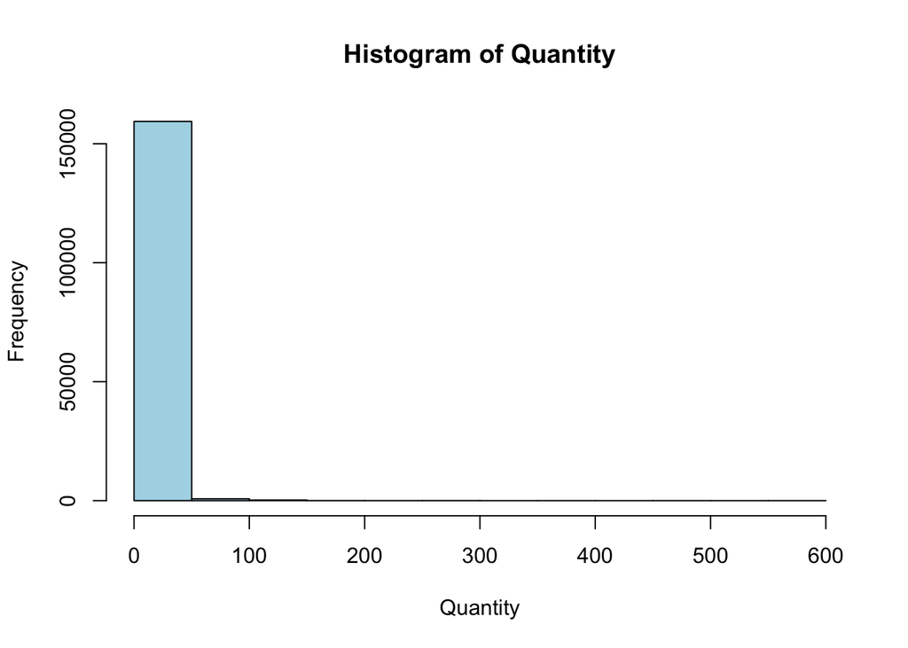

```r
hist(Retail_sales$Quantity, main = "Histogram of Quantity", xlab = "Quantity", col = "lightblue")
```

#### Histogram of Quantity plotted with the frequency of buyers, which shows us the amount of quantity bought by the most frequent buyers. Understanding this is important as this would help us find out if there are any patterns or inferences with regards to the most frequent buyers like the type of item most purchased or the country from where the customer belongs to or the time or the season of the year where a certain product is bough at an abnormal quantity.

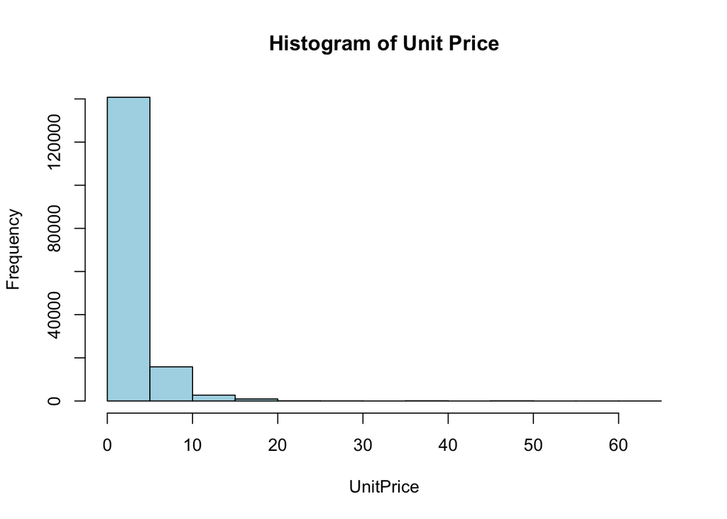

```r
hist(Retail_sales$UnitPrice, main = "Histogram of Unit Price", xlab = "UnitPrice", col = "lightblue")
```

#### The first bin contains the majority of the unit prices, suggesting that low-priced items are found there frequently. Higher unit price bins show a sharp decline in frequency, indicating that higher unit price items are significantly less common in this dataset. The short bars after the first bin indicate that there aren’t many products with unit prices between 10 and 60. According to this histogram, the dataset is primarily biased toward items with lower unit prices, with very few items having higher unit prices. A distribution like this could help with pricing plans and inventory choices.

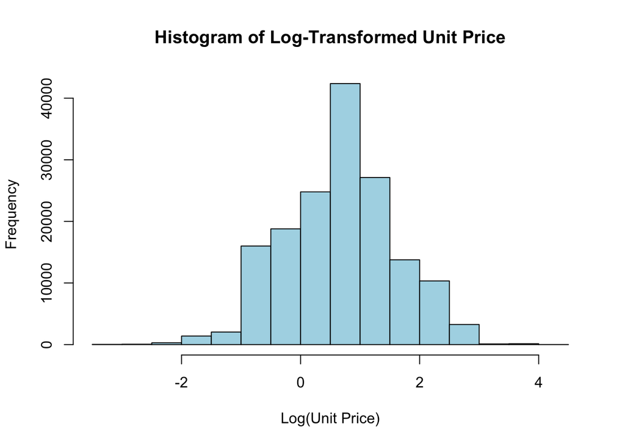

```r
log_unit_prices <- log(Retail_sales$UnitPrice)

hist(log_unit_prices,
     main = "Histogram of Log-Transformed Unit Price",
     xlab = "Log(Unit Price)",
     col = "lightblue")
```

#### The majority of the unit prices, when log-transformed, appear to fall within the range indicated by the histogram’s peak, which is located between 0 and 1 on the log scale. Unlike the right-skewed distribution that is frequently seen in raw monetary data, the bars are more evenly distributed across various ranges of log-transformed unit prices.

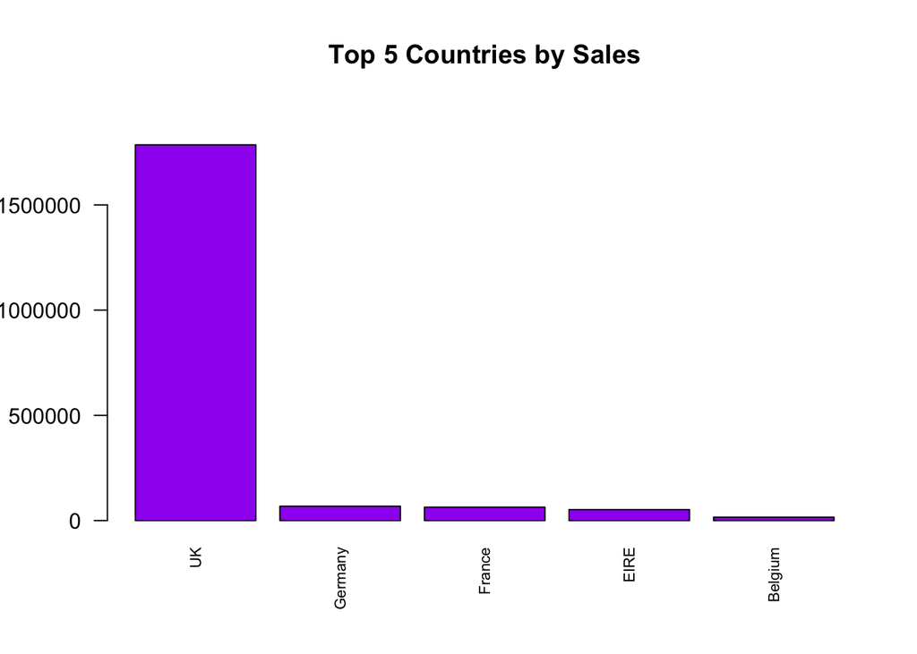

```r
country_sales <- aggregate(Totalsales ~ Country, data = Retail_sales, sum)

country_sales <- country_sales[order(-country_sales$Totalsales),]

top_5_country_sales <- head(country_sales, 5)

# Create a bar plot for the top 5 countries
barplot(top_5_country_sales$Totalsales,
        names.arg = top_5_country_sales$Country,
        las = 2,
        main = "Top 5 Countries by Sales",
        col="purple",
        cex.names = 0.7,
        ylim = c(0, max(top_5_country_sales$Totalsales) * 1.1))
```

#### Barplot of sales by countries. Here the UK has also been taken into consideration which clearly dominates the other markets, hence a clear tall bar can be seen next to overwhelmingly low sales in the rest of the participating countries. The main reason for this being the company is based out of the UK.

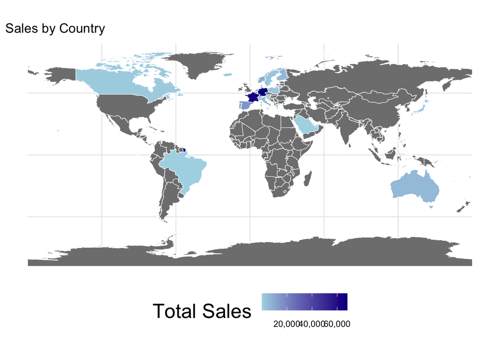

```r
library(ggplot2)
library(rnaturalearth)
library(sf)

salesbycountries <- aggregate(Totalsales ~ Country, data = Retail_sales, sum)

world_countries <- ne_countries(scale = "large", returnclass = "sf")
world_sales_map <- merge(world_countries, salesbycountries, by.x = "name", by.y = "Country", all.x = TRUE)

# Creating the world map

ggplot(data = world_sales_map) +
  geom_sf(aes(fill = Totalsales), color = "white", size = 0.1) +
  scale_fill_continuous(low = "lightblue", high = "darkblue", na.value = "grey50", name = "Total Sales", label = scales::comma) +
  labs(title = "Sales by Country") +
  theme_minimal() +
  theme(legend.position = "bottom",
        legend.title = element_text(size = 20))
```

```r
#Frequency of the dependent variable
total_sales_freq <- table(Retail_sales$Totalsales)

head(total_sales_freq)
```

```
##
## 0.06 0.08  0.1 0.12 0.14 0.16
##    1    1    3   11    2    1
```

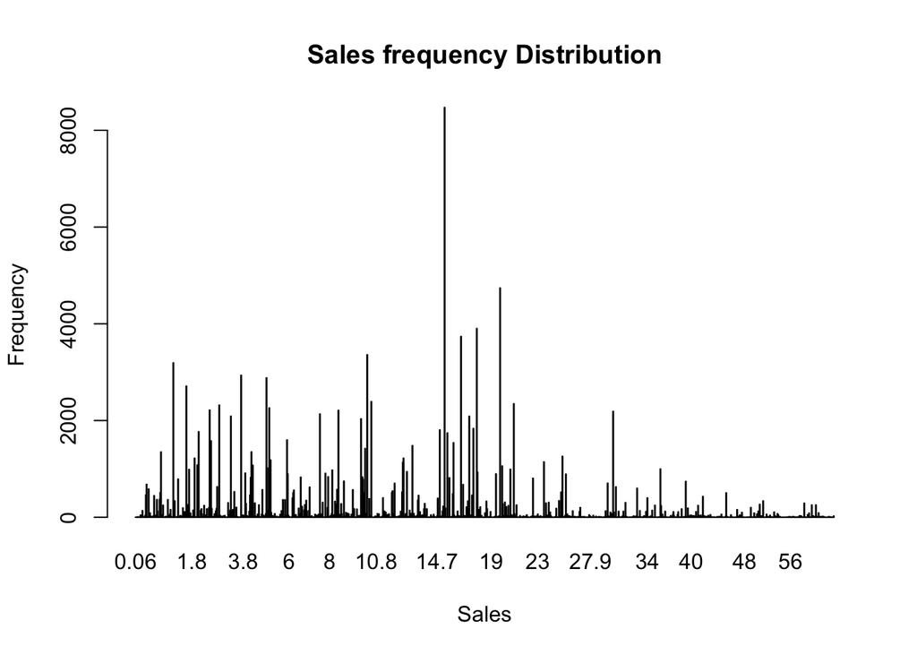

```r
#Plotting Sales frequency table to check for the balanced distribution

barplot(total_sales_freq, main="Sales frequency Distribution", xlab="Sales", ylab="Frequency")
```

#### The sales data appears to have a complex, multimodal distribution, with a range of sales amounts occurring at various frequencies, according to the chart. There seems to be a particularly noticeable peak in the range of sales values between 10 and 15, which suggests that sales amounts in this range occur frequently. A multimodal distribution is characterized by multiple smaller peaks spread across the range of sales values, indicating the presence of multiple modes in the data. Higher sales amounts (approaching 60) have significantly lower frequencies, suggesting that these higher sales values are less frequent.

```r
Median_sale <- median(Retail_sales$Totalsales, na.rm = TRUE)

Retail_sales$HighSale <- ifelse(Retail_sales$Totalsales > Median_sale, '0', '1')

table(Retail_sales$HighSale)
```

```
##
##     0     1
## 80188 80297
```

#### The last dummy variable is HighSale, As per the above table which represents 80297 as low sales when compared with 80188 as high sales is almost 1:1, which is a fairly balanced distribution. In this case, we can conclude that the dataset is not under or over sampled. Furthermore, this balanced dataset could be utilized directly to train and predict the classification models.

```r
High_quantity <- quantile(Retail_sales$Quantity, 0.75)
Low_price <- quantile(Retail_sales$UnitPrice, 0.25)

Retail_sales$Segments <- with(Retail_sales, ifelse(Quantity >= High_quantity & UnitPrice <= Low_price, 'HQLP',
                                  ifelse(Quantity < High_quantity & UnitPrice > Low_price, 'LQHP', 'Other')))

# Filter segments
HQLP_data <- subset(Retail_sales, Segments == 'HQLP')
LQHP_data <- subset(Retail_sales, Segments == 'LQHP')

# Descriptive statistics
summary(HQLP_data)
```

```
##    InvoiceNo       StockCode     Description           Quantity
##  571653 :   58   21212  :  296   Length:30874       Min.   : 12.00
##  574328 :   44   22197  :  239   Class :character   1st Qu.: 12.00
##  549577 :   40   84946  :  198   Mode  :character   Median : 18.00
##  570672 :   36   22993  :  192                      Mean   : 22.94
##  567183 :   34   84077  :  186                      3rd Qu.: 24.00
##  551351 :   33   21790  :  179                      Max.   :576.00
##  (Other):30629   (Other):29584
##   InvoiceDate           UnitPrice        CustomerID      Country
##  Min.   :2020-01-04   Min.   :0.0400   14911  :  724   Length:30874
##  1st Qu.:2020-05-06   1st Qu.:0.4200   14298  :  426   Class :character
##  Median :2020-08-19   Median :0.7900   13089  :  277   Mode  :character
##  Mean   :2020-07-30   Mean   :0.7575   13081  :  184
##  3rd Qu.:2020-10-28   3rd Qu.:1.2500   12748  :  178
##  Max.   :2020-12-23   Max.   :1.2500   15159  :  123
##                                        (Other):28962
##    Totalsales    GroupedCountry        Season           InvoiceDummy
##  Min.   : 0.78   Length:30874       Length:30874       Min.   :0
##  1st Qu.:10.08   Class :character   Class :character   1st Qu.:0
##  Median :13.20   Mode  :character   Mode  :character   Median :0
##  Mean   :15.04                                         Mean   :0
##  3rd Qu.:15.60                                         3rd Qu.:0
##  Max.   :65.28                                         Max.   :0
##
##  Log_Totalsales  Log_UnitPrice       HighSale           Segments
##  Min.   :2.485   Min.   :-3.2189   Length:30874       Length:30874
##  1st Qu.:2.485   1st Qu.:-0.8675   Class :character   Class :character
##  Median :2.890   Median :-0.2357   Mode  :character   Mode  :character
##  Mean   :2.952   Mean   :-0.4163
##  3rd Qu.:3.178   3rd Qu.: 0.2231
##  Max.   :6.356   Max.   : 0.2231
##
```

```r
summary(LQHP_data)
```

```
##    InvoiceNo       StockCode     Description           Quantity
##  579196 :  203   85123A :  585   Length:87649       Min.   : 1.000
##  576339 :  187   22423  :  549   Class :character   1st Qu.: 1.000
##  580727 :  185   85099B :  514   Mode  :character   Median : 3.000
##  578270 :  146   47566  :  493                      Mean   : 3.594
##  568346 :  136   20725  :  469                      3rd Qu.: 6.000
##  575607 :  134   22720  :  459                      Max.   :11.000
##  (Other):86658   (Other):84580
##   InvoiceDate           UnitPrice        CustomerID      Country
##  Min.   :2020-01-04   Min.   : 1.380   17841  : 1932   Length:87649
##  1st Qu.:2020-05-09   1st Qu.: 2.080   14096  : 1768   Class :character
##  Median :2020-08-30   Median : 2.950   14911  : 1141   Mode  :character
##  Mean   :2020-08-03   Mean   : 4.268   12748  : 1080
##  3rd Qu.:2020-11-06   3rd Qu.: 4.950   14606  :  715
##  Max.   :2020-12-23   Max.   :65.000   15311  :  502
##                                        (Other):80511
##    Totalsales    GroupedCountry        Season           InvoiceDummy
##  Min.   : 1.45   Length:87649       Length:87649       Min.   :0
##  1st Qu.: 4.95   Class :character   Class :character   1st Qu.:0
##  Median :11.85   Mode  :character   Mode  :character   Median :0
##  Mean   :12.61                                         Mean   :0
##  3rd Qu.:17.00                                         3rd Qu.:0
##  Max.   :65.20                                         Max.   :0
##
##  Log_Totalsales   Log_UnitPrice      HighSale           Segments
##  Min.   :0.0000   Min.   :0.3221   Length:87649       Length:87649
##  1st Qu.:0.0000   1st Qu.:0.7324   Class :character   Class :character
##  Median :1.0986   Median :1.0818   Mode  :character   Mode  :character
##  Mean   :0.9972   Mean   :1.2346
##  3rd Qu.:1.7918   3rd Qu.:1.5994
##  Max.   :2.3979   Max.   :4.1744
##
```

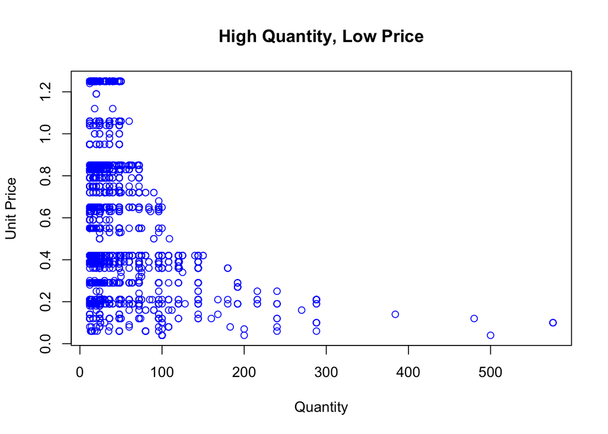

```r
# Visualization
# Scatter plot for HQLP
plot(HQLP_data$Quantity, HQLP_data$UnitPrice, main="High Quantity, Low Price", xlab="Quantity", ylab="Unit Price", col="blue")
```

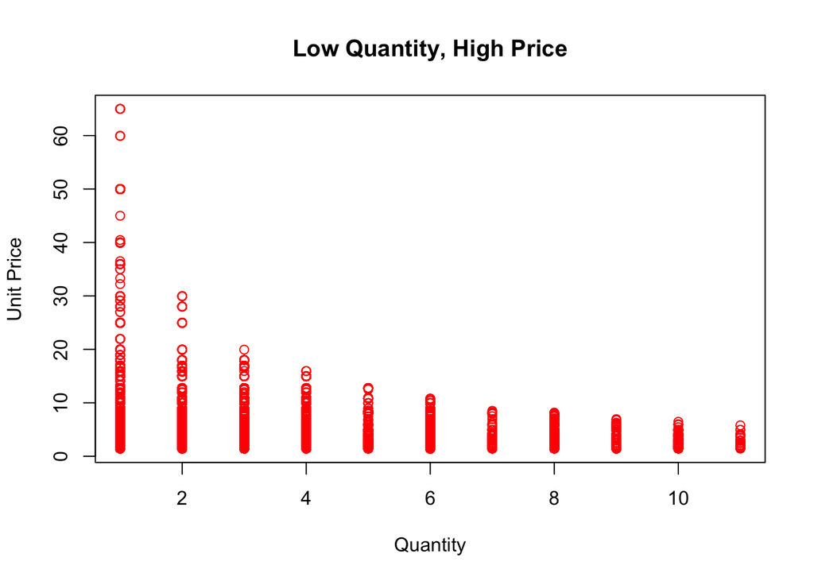

```r
# Scatter plot for LQHP
plot(LQHP_data$Quantity, LQHP_data$UnitPrice, main="Low Quantity, High Price", xlab="Quantity", ylab="Unit Price", col="red")
```

```r
# Calculate total sales
total_sales_by_segment <- Retail_sales %>%
  group_by(Segments) %>%
  summarise(Totalsales = sum(Totalsales))

# Print the table
print(total_sales_by_segment)
```

```
## # A tibble: 3 × 2
##   Segments Totalsales
##   <chr>         <dbl>
## 1 HQLP        464306.
## 2 LQHP       1105287.
## 3 Other       531260.
```

#### LQHP - The number of items is represented by the “Quantity” x-axis, which goes from 1 to slightly over 10. Prices are displayed on the “Unit Price” y-axis, which spans from 0 to more than 60. The vertically distributed data points display a broad range of prices for small quantities of goods. The quantity and the unit price do not appear to be directly correlated, though it appears that the unit prices can differ significantly even at lower quantities. The phrase “Low Quantity, High Price” implies that the data show products that are sold in small amounts but for a higher price; these products may be luxury or high-end items.

```r
# Correlation analysis
cor(HQLP_data$Quantity, HQLP_data$UnitPrice)
```

```
## [1] -0.309629
```

```r
cor(LQHP_data$Quantity, LQHP_data$UnitPrice)
```

```
## [1] -0.2880264
```

```r
# Regression analysis (if it makes sense)
lm_HQLP <- lm(UnitPrice ~ Quantity, data=HQLP_data)
lm_LQHP <- lm(UnitPrice ~ Quantity, data=LQHP_data)

# Summarize regression results
summary(lm_HQLP)
```

```
##
## Call:
## lm(formula = UnitPrice ~ Quantity, data = HQLP_data)
##
## Residuals:
##      Min       1Q   Median       3Q      Max
## -0.75158 -0.32629  0.01651  0.43298  2.35191
##
## Coefficients:
##               Estimate Std. Error t value Pr(>|t|)
## (Intercept)  0.8823204  0.0029413  299.97   <2e-16 ***
## Quantity    -0.0054414  0.0000951  -57.22   <2e-16 ***
## ---
## Signif. codes:  0 '***' 0.001 '**' 0.01 '*' 0.05 '.' 0.1 ' ' 1
##
## Residual standard error: 0.3466 on 30872 degrees of freedom
## Multiple R-squared:  0.09587,    Adjusted R-squared:  0.09584
## F-statistic:  3274 on 1 and 30872 DF,  p-value: < 2.2e-16
```

```r
summary(lm_LQHP)
```

```
##
## Call:
## lm(formula = UnitPrice ~ Quantity, data = LQHP_data)
##
## Residuals:
##    Min     1Q Median     3Q    Max
## -3.805 -2.083 -0.403  0.836 59.745
##
## Coefficients:
##              Estimate Std. Error t value Pr(>|t|)
## (Intercept)  5.635505   0.019149  294.29   <2e-16 ***
## Quantity    -0.380439   0.004272  -89.04   <2e-16 ***
## ---
## Signif. codes:  0 '***' 0.001 '**' 0.01 '*' 0.05 '.' 0.1 ' ' 1
##
## Residual standard error: 3.388 on 87647 degrees of freedom
## Multiple R-squared:  0.08296,    Adjusted R-squared:  0.08295
## F-statistic:  7929 on 1 and 87647 DF,  p-value: < 2.2e-16
```

```r
customer_order_freq <- Retail_sales %>%
  group_by(CustomerID) %>%
  summarize(OrderFrequency = n_distinct(InvoiceNo))

freq_quantiles <- quantile(customer_order_freq$OrderFrequency, probs = c(0.25, 0.75))

customer_order_freq$Cust.Frequency <- cut(customer_order_freq$OrderFrequency,
                                          breaks = c(-Inf, freq_quantiles, Inf),
                                          labels = c("Rare", "Moderate", "Frequent"),
                                          include.lowest = TRUE)

Retail_sales <- merge(Retail_sales, customer_order_freq, by = "CustomerID")
```

```r
description_freq <- Retail_sales %>%
  group_by(Description) %>%
  summarize(Des_Frequency = n_distinct(InvoiceNo))

freq_quantiles <- quantile(description_freq$Des_Frequency, probs = c(0.25, 0.75))

description_freq$Item.Frequency <- cut(description_freq$Des_Frequency,
                                       breaks = c(-Inf, freq_quantiles, Inf),
                                       labels = c("Rare", "Moderate", "Frequent"),
                                       include.lowest = TRUE)

Retail_sales <- merge(Retail_sales, description_freq, by = "Description")

Retail_sales$Log_Totalsales <- log(Retail_sales$Totalsales)
Retail_sales$Log_Quantity <- log(Retail_sales$Quantity)

dim(Retail_sales)
```

```
## [1] 160485     21
```

```r
head(Retail_sales)
```

```
##              Description CustomerID InvoiceNo StockCode Quantity InvoiceDate
## 1 10 Colour Spaceboy Pen      12567    537468     22418       24  2020-12-07
## 2 10 Colour Spaceboy Pen      16205    569302     22418       12  2020-10-03
## 3 10 Colour Spaceboy Pen      12856    573544     22418       12  2020-10-31
## 4 10 Colour Spaceboy Pen      17043    571746     22418       24  2020-10-19
## 5 10 Colour Spaceboy Pen      16053    574830     22418       24  2020-11-07
## 6 10 Colour Spaceboy Pen      12621    564140     22418       24  2020-08-23
##   UnitPrice Country Totalsales GroupedCountry Season InvoiceDummy
## 1      0.85  France       20.4          Other Winter            0
## 2      0.85      UK       10.2             UK   Fall            0
## 3      0.85      UK       10.2             UK   Fall            0
## 4      0.85      UK       20.4             UK   Fall            0
## 5      0.85      UK       20.4             UK   Fall            0
## 6      0.85 Germany       20.4          Other Summer            0
##   Log_Totalsales Log_UnitPrice HighSale Segments OrderFrequency Cust.Frequency
## 1       3.015535    -0.1625189        0     HQLP             10       Frequent
## 2       2.322388    -0.1625189        1     HQLP              3       Moderate
## 3       2.322388    -0.1625189        1     HQLP              6       Frequent
## 4       3.015535    -0.1625189        0     HQLP              4       Moderate
## 5       3.015535    -0.1625189        0     HQLP              2       Moderate
## 6       3.015535    -0.1625189        0     HQLP             18       Frequent
##   Des_Frequency Item.Frequency Log_Quantity
## 1            99       Frequent     3.178054
## 2            99       Frequent     2.484907
## 3            99       Frequent     2.484907
## 4            99       Frequent     3.178054
## 5            99       Frequent     3.178054
## 6            99       Frequent     3.178054
```

```r
library(dplyr)
library(lubridate)

# Let's set analysis date as one day after the last invoice date in the Retail dataset
retail_analysis_date <- max(Retail_sales$InvoiceDate) + days(1)

rfm_table <- Retail_sales %>%
             group_by(CustomerID) %>%
             summarize(Recency = as.numeric(retail_analysis_date - max(InvoiceDate)),
                       Frequency = n_distinct(InvoiceNo),
                       Monetary = sum(Totalsales))

rfm_table <- rfm_table %>%
             mutate(R_Score = ntile(-Recency, 5),
                    F_Score = ntile(Frequency, 5),
                    M_Score = ntile(Monetary, 5))


rfm_table <- rfm_table %>%
             mutate(RFM_Score = R_Score + F_Score + M_Score)
```

```r
library(knitr)

rfm_results <- rfm_table %>%
                       group_by(RFM_Score) %>%
                       summarize(Min_Recency = min(Recency),
                                 Max_Recency = max(Recency),
                                 Min_Frequency = min(Frequency),
                                 Max_Frequency = max(Frequency),
                                 Min_Monetary = min(Monetary),
                                 Max_Monetary = max(Monetary))

rfm_results <- kable(rfm_results, format = "html", caption = "RFM Segment Characteristics")

print(rfm_results)
```

[output not shown]

[output cut: 78 more lines]

```
##    <td style="text-align:right;"> 43 </td>
##    <td style="text-align:right;"> 328.20 </td>
##    <td style="text-align:right;"> 20422.38 </td>
##   </tr>
##   <tr>
##    <td style="text-align:right;"> 15 </td>
##    <td style="text-align:right;"> 1 </td>
##    <td style="text-align:right;"> 18 </td>
##    <td style="text-align:right;"> 5 </td>
##    <td style="text-align:right;"> 186 </td>
##    <td style="text-align:right;"> 709.09 </td>
##    <td style="text-align:right;"> 43646.75 </td>
##   </tr>
## </tbody>
## </table>
```

```r
top_customers <- rfm_table %>%
                 arrange(desc(Monetary))

head(top_customers)
```

```
## # A tibble: 6 × 8
##   CustomerID Recency Frequency Monetary R_Score F_Score M_Score RFM_Score
##   <fct>        <dbl>     <int>    <dbl>   <int>   <int>   <int>     <int>
## 1 14911            1       186   43647.       5       5       5        15
## 2 14096           19        17   20422.       4       5       5        14
## 3 14298            4        38   16415.       5       5       5        15
## 4 13089            8        82   16396.       5       5       5        15
## 5 17841            5       120   15901.       5       5       5        15
## 6 12748            1       176   11425.       5       5       5        15
```

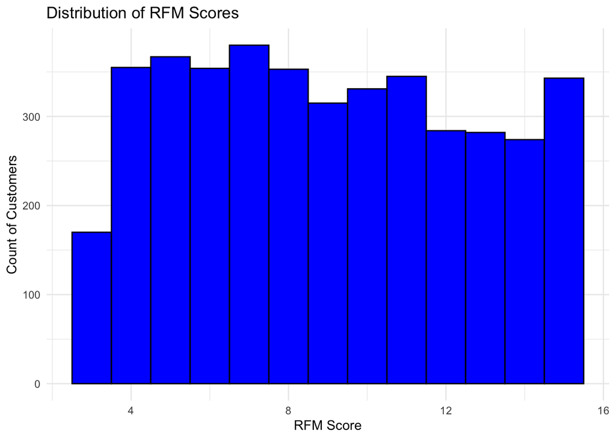

```r
# Plotting the distribution of R, F, and M scores
Cust_RFM <- ggplot(rfm_table, aes(x = RFM_Score)) +
  geom_histogram(binwidth = 1, fill = "blue", color = "black") +
  labs(title = "Distribution of RFM Scores", x = "RFM Score", y = "Count of Customers") +
  theme_minimal()

Cust_RFM
```

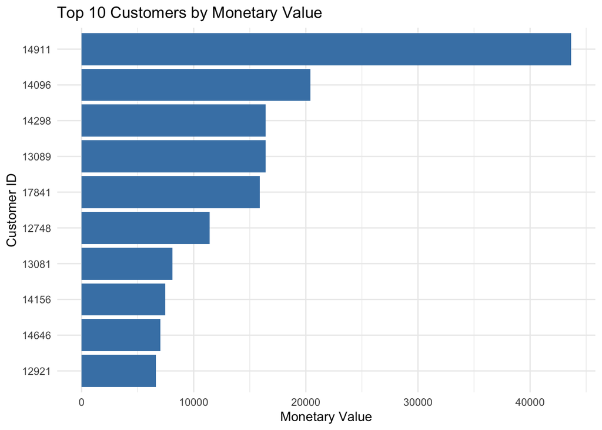

```r
top_customers <- head(top_customers, 10)

Cust_Mont <- ggplot(top_customers, aes(x = reorder(CustomerID, Monetary), y = Monetary)) +
  geom_bar(stat = "identity", fill = "steelblue") +
  coord_flip() +
  labs(title = "Top 10 Customers by Monetary Value", x = "Customer ID", y = "Monetary Value") +
  theme_minimal()

Cust_Mont
```

#### Top 10 Customers by Monetary Value - When displaying data in descending order, this kind of chart is frequently used to quickly identify the top items—in this case, the top customers based on the dollar amount of their purchases. Customer IDs, or unique customer identifiers, are listed on the y-axis. These IDs are numbers, such as 14096, 14298, 14911, and so on. The Monetary Value, shown on the x-axis, is most likely the total amount spent or revenue contributed by each customer. The monetary value range is indicated by the scale, which appears to go from 0 to more than 40,000. The length of each bar represents the total monetary value assigned to that particular customer; the customer with the highest monetary value is represented by the longest bar at the top, and those with lower monetary values are represented by shorter bars. The remaining customers are arranged in order of highest to lowest value. Of the top 10, Customer 12921 has the lowest monetary value, but it is still significant enough to be displayed in this chart. A company could use this chart to determine which of its clients are the most valuable, and then use that information to target retention campaigns, customized marketing campaigns, or other customer engagement initiatives. It also exemplifies the Pareto 80/20 rule, which is applicable in many business contexts and states that a small percentage of revenue may come from a small number of customers.

## Data Partitioning of Retail sales data

```r
library(caret)

set.seed(123)
train_data_obs <- sample(rownames(Retail_sales), dim(Retail_sales)[1]*0.6)
train_data <- Retail_sales[train_data_obs, ]
valid_data_obs <- setdiff(rownames(Retail_sales), train_data_obs)
valid_data <- Retail_sales[valid_data_obs, ]

dim(train_data)
```

```
## [1] 96291    21
```

```r
dim(valid_data)
```

```
## [1] 64194    21
```

### Model 1: Multi Linear Regression Model

```r
library(stargazer)
# Running the multi linear regression model

regressmodel1 <- lm(Log_Quantity ~ Season + GroupedCountry, data = train_data)

summary(regressmodel1)
```

```
##
## Call:
## lm(formula = Log_Quantity ~ Season + GroupedCountry, data = train_data)
##
## Residuals:
##     Min      1Q  Median      3Q     Max
## -2.1653 -0.8140 -0.0345  0.9463  4.9398
##
## Coefficients:
##                   Estimate Std. Error t value Pr(>|t|)
## (Intercept)       2.047523   0.011709 174.873   <2e-16 ***
## SeasonSpring      0.086388   0.009621   8.979   <2e-16 ***
## SeasonSummer      0.117808   0.009485  12.420   <2e-16 ***
## SeasonWinter     -0.004478   0.009352  -0.479    0.632
## GroupedCountryUK -0.626740   0.011424 -54.863   <2e-16 ***
## ---
## Signif. codes:  0 '***' 0.001 '**' 0.01 '*' 0.05 '.' 0.1 ' ' 1
##
## Residual standard error: 1.076 on 96286 degrees of freedom
## Multiple R-squared:  0.03292,    Adjusted R-squared:  0.03288
## F-statistic: 819.4 on 4 and 96286 DF,  p-value: < 2.2e-16
```

#### Using a training dataset called train_data, multilinear regression is performed with Log_Quantity as the dependent variable and Season and GroupedCountry as the independent variables. The intercept is 2.0475, which indicates that the expected value of Log_Quantity is approximately 2.048 if all other variables are zero. This is statistically very significant. With positive coefficients of 0.0864 and 0.1178, respectively, SeasonSpring and SeasonSummer are linked to higher Log_Quantity values than the baseline season— Autumn and are both highly significant.The data for SeasonWinter indicates a small negative coefficient (-0.0045) but no statistically significant difference in Log_Quantity between Winter and the baseline (p-value 0.632). The significant negative coefficient (-0.6267) of GroupedCountryUK indicates that residing in the UK is linked to a decline in Log_Quantity. The actual values generally differ by this amount from the predicted values, as indicated by the residual standard error of 1.076. With an R-squared of 0.03292, the model can only account for roughly 3.29% of the variability in Log_Quantity. Given the low value, it is possible that the model does not account for other significant variables.

```r
regressmodel2 <- lm(Log_Quantity ~ Log_UnitPrice + Season + GroupedCountry + Item.Frequency + Cust.Frequency, data = train_data)

stargazer(regressmodel2, type = "text")
```

```
##
## ===================================================
##                            Dependent variable:
##                        ----------------------------
##                                Log_Quantity
## ---------------------------------------------------
## Log_UnitPrice                   -0.579***
##                                  (0.003)
##
## SeasonSpring                     0.121***
##                                  (0.008)
##
## SeasonSummer                     0.102***
##                                  (0.008)
##
## SeasonWinter                     0.041***
##                                  (0.008)
##
## GroupedCountryUK                -0.666***
##                                  (0.010)
##
## Item.FrequencyModerate           0.098***
##                                  (0.026)
##
## Item.FrequencyFrequent           0.269***
##                                  (0.025)
##
## Cust.FrequencyModerate           0.041***
##                                  (0.011)
##
## Cust.FrequencyFrequent           0.053***
##                                  (0.011)
##
## Constant                         2.167***
##                                  (0.029)
##
## ---------------------------------------------------
## Observations                      96,291
## R2                                0.272
## Adjusted R2                       0.272
## Residual Std. Error         0.933 (df = 96281)
## F Statistic            3,995.227*** (df = 9; 96281)
## ===================================================
## Note:                   *p<0.1; **p<0.05; ***p<0.01
```

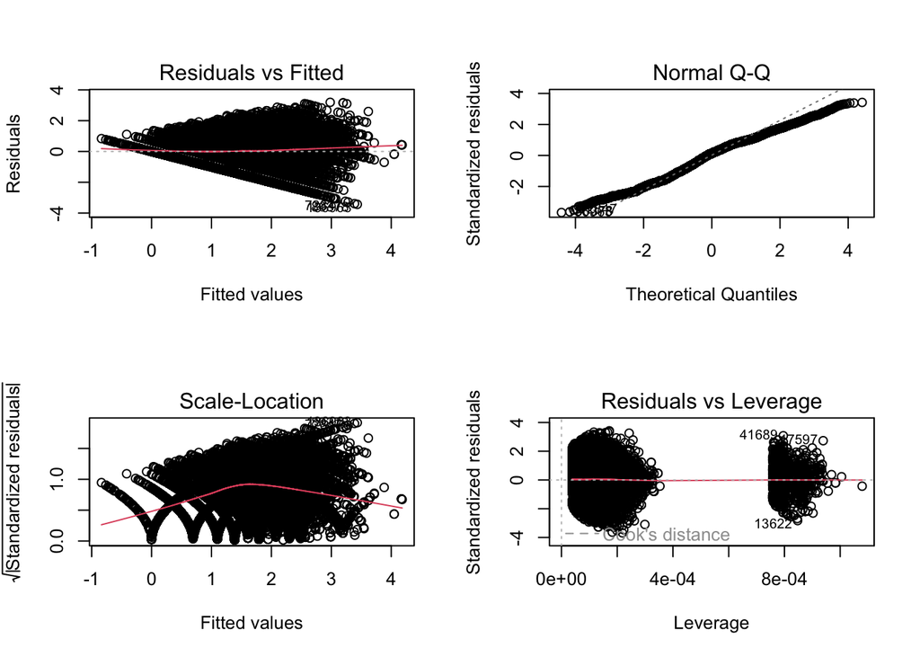

```r
par(mfrow=c(2,2))
plot(regressmodel2)
```

#### A linear regression model’s diagnostic plots, shown above, are intended to evaluate the soundness of the model’s underlying assumptions. Residuals versus Fitted Plot: This compares the residuals’ variance to ensure that they are homoscedastic, or non-linear. The residuals should ideally be distributed randomly along the horizontal line. The residuals in this case appear to follow a pattern that suggests possible heteroscedasticity and non-linearity as the fitted values rise. The Normal Q-Q Plot evaluates the normality of the residual distribution. The lines that follow imply normalcy. Possible deviations from normalcy are indicated by this plot’s deviations from the straight line, particularly at the tails. Spread-Location, also called Scale-Location Plot: This is an additional homoscedasticity check. Heteroscedasticity in the data is suggested by the plot’s widening spread. Leverage vs. Residuals Plot: This finds significant observations that might significantly affect the regression line. It is possible that points outside of the dashed Cook’s distance lines have an impact. There are a few higher leverage points in the plot, but they don’t seem to be outside of Cook’s distance lines, indicating that there aren’t any specific problems with significant outliers.

```r
regressmodel1_pred <- predict(regressmodel1, newdata = valid_data)
rmse1 <- sqrt(mean((regressmodel1_pred - valid_data$Log_Quantity)^2))
print(rmse1)
```

```
## [1] 1.074334
```

```r
regressmodel2_pred <- predict(regressmodel2, newdata = valid_data)
rmse2 <- sqrt(mean((regressmodel2_pred - valid_data$Log_Quantity)^2))
print(rmse2)
```

```
## [1] 0.9340931
```

### Model 2: Random Forest Model

```r
## Running Random Forest model

library(randomForest)

set.seed(123)
sales_rf1 <- randomForest(Log_Quantity ~ Season + GroupedCountry + Item.Frequency + Cust.Frequency, data = train_data, ntree = 500, importance = TRUE)

print(sales_rf1)
```

```
##
## Call:
##  randomForest(formula = Log_Quantity ~ Season + GroupedCountry +      Item.Frequency + Cust.Frequency, data = train_data, ntree = 500,      importance = TRUE)
##                Type of random forest: regression
##                      Number of trees: 500
## No. of variables tried at each split: 1
##
##           Mean of squared residuals: 1.159113
##                     % Var explained: 3.1
```

#### % Var explained: 3.1 - The target variable, Log_Quantity, has a variance that this model explains of 3.1%. This low percentage indicates that not all of the variability in the data is being captured by the model, which could be because explanatory variables are missing or the underlying relationship is complex. In conclusion, a large ensemble of trees was used to build the random forest model, which predicts Log_Quantity, but its predictive power is limited because it only accounts for a small percentage of the data’s variance. To increase the % of variance explained, it could be helpful to look into the features, add more pertinent predictors, or experiment with different modeling approaches.

```r
set.seed(123)

sales_rf2 <- randomForest(Log_Quantity ~ Log_UnitPrice + Season + GroupedCountry + Item.Frequency + Cust.Frequency, data = train_data, ntree = 500, importance = TRUE)


print(sales_rf2)
```

```
##
## Call:
##  randomForest(formula = Log_Quantity ~ Log_UnitPrice + Season +      GroupedCountry + Item.Frequency + Cust.Frequency, data = train_data,      ntree = 500, importance = TRUE)
##                Type of random forest: regression
##                      Number of trees: 500
## No. of variables tried at each split: 1
##
##           Mean of squared residuals: 0.9564134
##                     % Var explained: 20.05
```

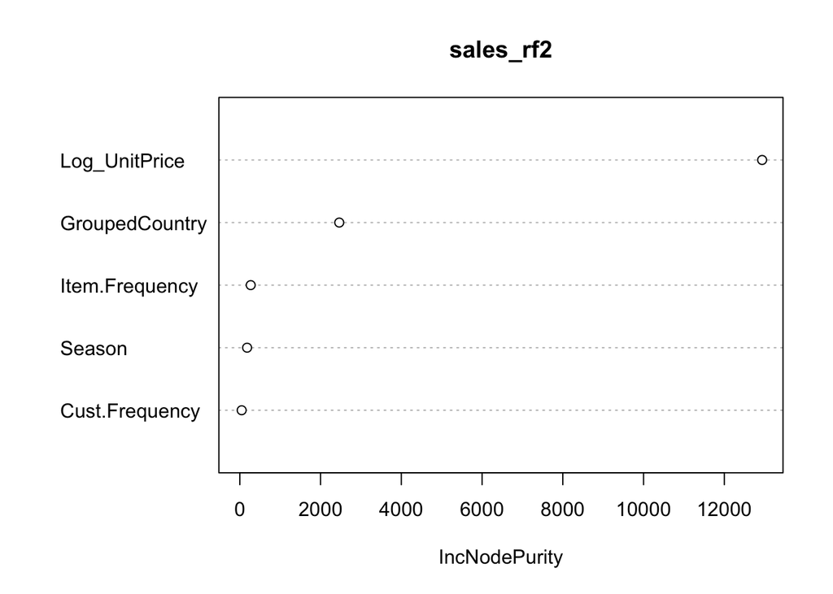

```r
## Lets plot the results of the random forest
varImpPlot(sales_rf2, type = 2)
```

#### The Variable Importance Plot from a Random Forest model shows that Log_UnitPrice is the most influential variable in predicting Log_Quantity, with GroupedCountry also having a notable impact. Variables like Item.Frequency, Season, and Cust.Frequency are less important. The plot, which measures variable importance by the increase in node purity, aids in identifying which features are most predictive for further analysis and model refinement. Overall, the model provides insights into key factors affecting sales quantity, useful for guiding business strategies.

```r
rf_prediction1 <- predict(sales_rf1, newdata = valid_data)

# Calculating RMSE
rmse3 <- sqrt(mean((rf_prediction1 - valid_data$Log_Quantity)^2))

# Printing the RMSE
print(rmse3)
```

```
## [1] 1.074723
```

```r
rf_prediction2 <- predict(sales_rf2, newdata = valid_data)

# Calculating RMSE
rmse4 <- sqrt(mean((rf_prediction2 - valid_data$Log_Quantity)^2))

# Printing the RMSE
print(rmse4)
```

```
## [1] 0.9765617
```

### Model 3: Regression tree

```r
library(rpart)

tree_model <- rpart(Log_Quantity ~ Log_UnitPrice + Season + GroupedCountry + Item.Frequency + Cust.Frequency, data = train_data, method = "anova")

# Print the summary of the tree model
printcp(tree_model)
```

```
##
## Regression tree:
## rpart(formula = Log_Quantity ~ Log_UnitPrice + Season + GroupedCountry +
##     Item.Frequency + Cust.Frequency, data = train_data, method = "anova")
##
## Variables actually used in tree construction:
## [1] GroupedCountry Log_UnitPrice
##
## Root node error: 115186/96291 = 1.1962
##
## n= 96291
##
##         CP nsplit rel error  xerror      xstd
## 1 0.152486      0   1.00000 1.00001 0.0035300
## 2 0.043562      1   0.84751 0.84753 0.0032691
## 3 0.023741      2   0.80395 0.80400 0.0030685
## 4 0.022774      3   0.78021 0.78027 0.0030686
## 5 0.010000      4   0.75744 0.75750 0.0030354
```

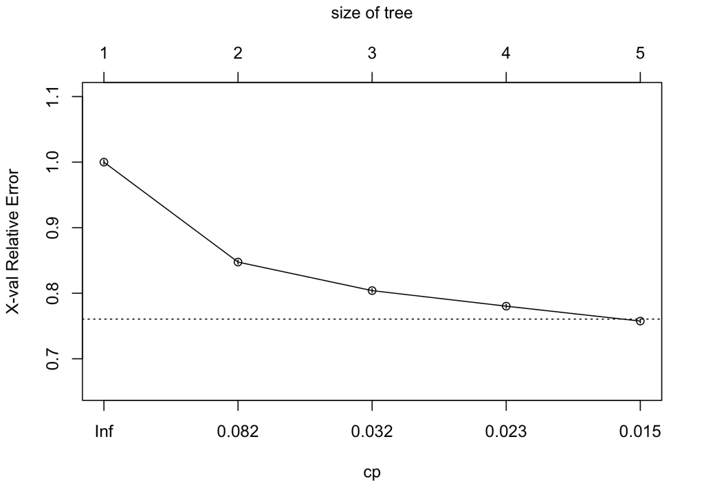

```r
plotcp(tree_model)
```

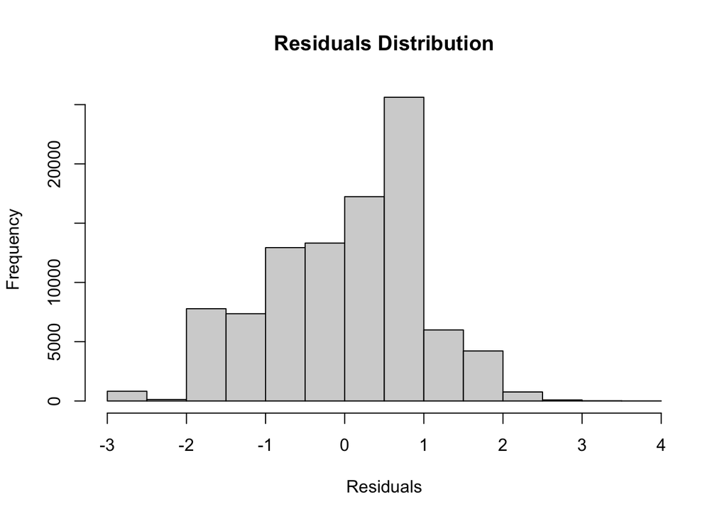

```r
# Cross Validation

residuals <- residuals(tree_model)
hist(residuals, main = "Residuals Distribution", xlab = "Residuals")
```

```r
cv_tree_model <- rpart(Log_Quantity ~ Log_UnitPrice + Season + GroupedCountry + Item.Frequency + Cust.Frequency,
                       data = train_data,
                       method = "anova",
                       xval = 10)
printcp(cv_tree_model)
```

```
##
## Regression tree:
## rpart(formula = Log_Quantity ~ Log_UnitPrice + Season + GroupedCountry +
##     Item.Frequency + Cust.Frequency, data = train_data, method = "anova",
##     xval = 10)
##
## Variables actually used in tree construction:
## [1] GroupedCountry Log_UnitPrice
##
## Root node error: 115186/96291 = 1.1962
##
## n= 96291
##
##         CP nsplit rel error  xerror      xstd
## 1 0.152486      0   1.00000 1.00001 0.0035299
## 2 0.043562      1   0.84751 0.84756 0.0032692
## 3 0.023741      2   0.80395 0.80403 0.0030687
## 4 0.022774      3   0.78021 0.78030 0.0030688
## 5 0.010000      4   0.75744 0.75754 0.0030357
```

#### The result of a regression tree model whose objective was to predict Log_Quantity based on multiple predictor variables and which was constructed using R’s rpart function. This is a thorough analysis of the result: Item.Frequency + Cust.Frequency + Season + GroupedCountry + Log_Quantity ~ Log_UnitPrice: This formula shows that the factors Log_UnitPrice, Season, GroupedCountry, Item.Frequency, and Cust.Frequency are being modeled in relation to Log_Quantity. data = train_data: The train_data dataset is used to train the model. method = “anova”: Analysis of variance is the basis for the splitting criterion, and it is suitable for continuous response variables. xval = 10: Ten folds are used for cross-validation, which divides the training data into ten parts. The model is trained on nine of the parts while being tested on each part. In conclusion, the regression tree model shows that GroupedCountry and Log_UnitPrice are important predictors of Log_Quantity. After four splits, the model’s error does not considerably decrease, indicating that a more basic model might work well enough. The model’s performance on the training data is expected to generalize to new data, according to the cross-validation.

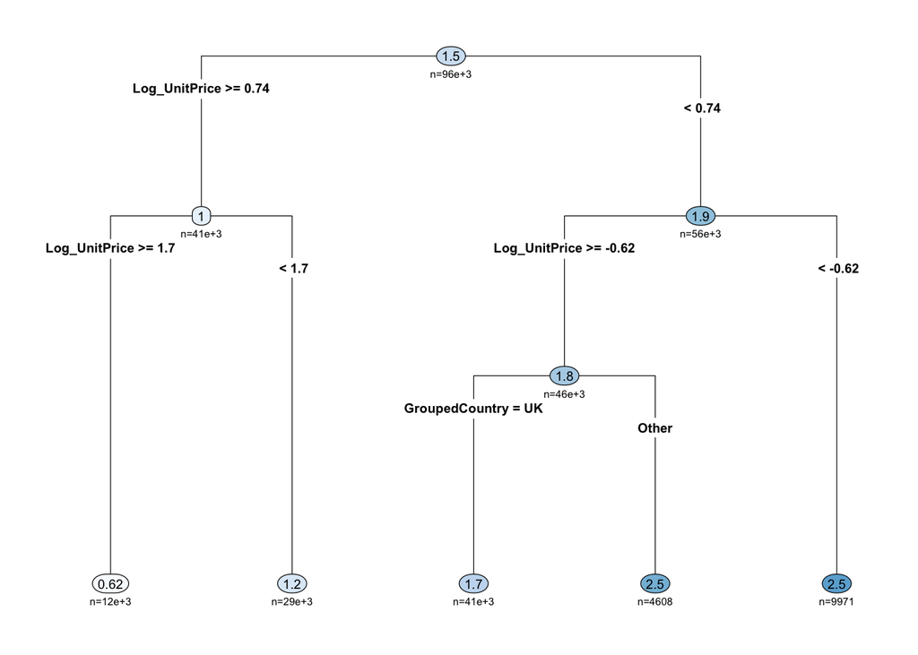

```r
# Plotting the regression tree

library(rpart.plot)
rpart.plot(tree_model, type = 4, extra = 1, under = TRUE, faclen = 0, cex = 0.6)
```

#### At 0.74, the tree first splits on Log_UnitPrice. It splits at Log_UnitPrice of 1.7 if Log_UnitPrice is greater than or equal to 0.74. With 56e+3 samples, the expected value is 1.9 if Log_UnitPrice is less than 0.74. In the event that Log_UnitPrice is 0.74 or higher: With 12e+3 samples, the expected value is 0.62 if Log_UnitPrice is greater than or equal to 1.7.With 29e+3 samples, the expected value is 1.2 if Log_UnitPrice is less than 1.7.The structure splits at -0.62 on Log_UnitPrice if Log_UnitPrice is less than 0.74. It looks for GroupedCountry if Log_UnitPrice is greater than or equal to -0.62. With 41e+3 samples, the expected value is 1.7 if GroupedCountry is the UK. If not, 2.5 (with 4608) is the expected value.

```r
# Evaluating predictive performance
predictions <- predict(tree_model, newdata = valid_data)
rmse5 <- sqrt(mean((predictions - valid_data$Log_Quantity)^2))
print(rmse5)
```

```
## [1] 0.952031
```

#### Assessing a predictive model’s performance on a validation dataset, in this case a tree-based regression model.Here is a detailed explanation: predictions - predict(tree_model, newdata = valid_data): This line uses valid_data as the input and the predict() function to produce predictions from tree_model. forecasts are expected to be a vector with the dependent variable’s (probably Log_Quantity) predicted values. Mean((predictions - valid_data$Log_Quantity)^2)) = rmse5 <- sqrt The Root Mean Square Error (RMSE) for the model’s predictions is computed on this line. It accomplishes this by: subtracting the expected values from the validation dataset’s actual Log_Quantity values.

```r
rmse_results <- data.frame(
  Model = c("Multi Linear Regression", "Random Forest Model", "Regression Tree"),
  RMSE = c(rmse2, rmse4, rmse5)
)

knitr::kable(rmse_results, caption = "Comparison results of Model RMSE's")
```

Comparison results of Model RMSE’s

| Model | RMSE |
| --- | --- |
| Multi Linear Regression | 0.9340931 |
| Random Forest Model | 0.9765617 |
| Regression Tree | 0.9520310 |

#### The most common method for calculating a model’s prediction error for quantitative data is to use the Root Mean Square Error (RMSE). A better fit between the model and the data is indicated by lower RMSE values. Considering the given RMSEs:Of the three models tested, the Multiple Linear Regression model has the lowest RMSE (0.9340931), suggesting that it has the best predictive accuracy for the tested data.

#### For this specific dataset, the Random Forest Model has the highest RMSE (0.9765617), indicating that it has the lowest predictive accuracy. In terms of predictive accuracy, the Regression Tree model is in the middle with an RMSE (0.9520310) that is marginally higher than that of the Multiple Linear Regression but lower than that of the Random Forest Model.

### Decile charts

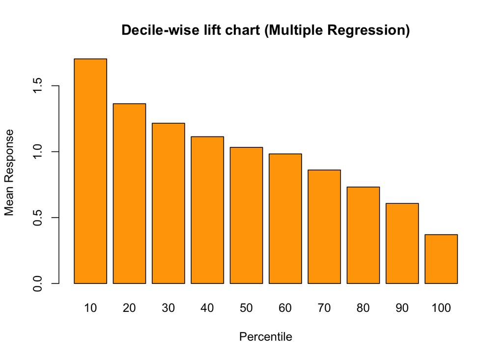

```r
library(gains)

gain <- gains(valid_data$Log_Quantity, regressmodel2_pred,)

barplot(gain$mean.resp / mean(valid_data$Log_Quantity), names.arg = gain$depth, xlab = "Percentile",
ylab = "Mean Response", main = "Decile-wise lift chart (Multiple Regression)",col='Orange')
```

#### Deciles (10%, 20%, etc.) on the independent variable is used to rank the dataset according to the values predicted by the model. The mean actual response within each decile is plotted on the independent variable side. The model appears to be most accurate for the top 10% of predictions, based on the tallest bar at the 10th percentile. The model’s predictive power decreases for lower-ranked predictions, as evidenced by the mean response declining across the deciles. In line with the lowest expectations, the smallest bar at the 100th percentile displays the lowest mean response. In conclusion, the model predicts higher responses more accurately than lower ones, which may be helpful for resource allocation or marketing targeting strategies.

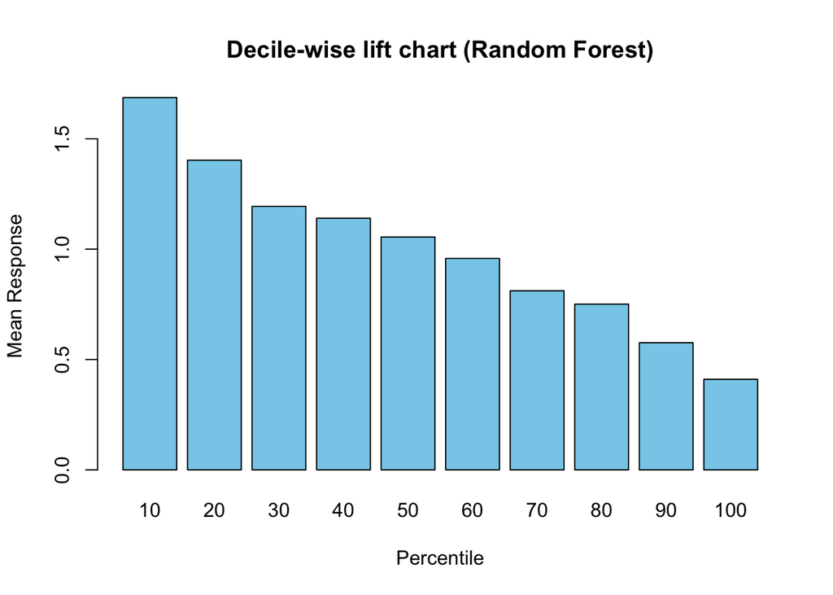

```r
gain <- gains(valid_data$Log_Quantity, rf_prediction2,)

barplot(gain$mean.resp / mean(valid_data$Log_Quantity), names.arg = gain$depth, xlab = "Percentile",
ylab = "Mean Response", main = "Decile-wise lift chart (Random Forest)", col='Skyblue')
```

#### The height of each bar represents the average response for that decile. A higher mean response is indicated by a higher bar. The model’s predictions and actual results match, as seen by the descending pattern from the first to the last decile; the highest predicted values match higher actual values, indicating that the model has good predictive power.

```r
gain <- gains(valid_data$Log_Quantity, predictions,)
```

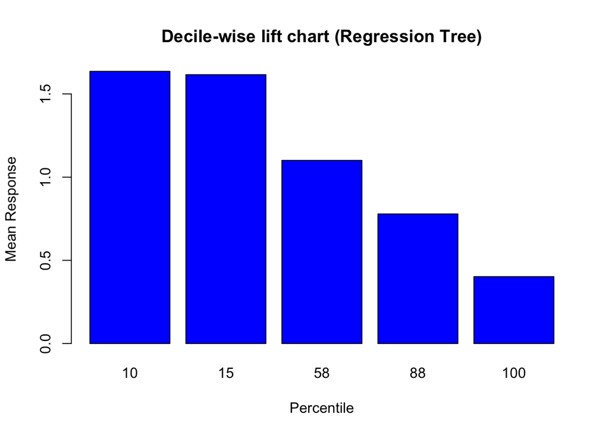

```r
barplot(gain$mean.resp / mean(valid_data$Log_Quantity), names.arg = gain$depth, xlab = "Percentile",
ylab = "Mean Response", main = "Decile-wise lift chart (Regression Tree)", col='Blue')
```

#### The bars show the average response for each decile, which is probably a target variable like sales or conversion rate.The model’s effective prediction of a higher outcome appears to be supported by the higher mean responses of the first two deciles (10 and 15). From the second decile to the third (58), there is a discernible decline in the mean response, suggesting a decline in the anticipated result. The last decile (100) has the lowest mean response, indicating that the model predicts the lowest outcomes for this group. The decile labeled 88 exhibits a further decline.